# glm

Marcela

16 de agosto de 2020

Analizaremos los datos $\mathtt{Default}$ de la libreria $\mathtt{ISLR},$ que consisten en 10.000 observaciones de informacion bancaria, contamos con las variables regresoras $\mathtt{balance},$ $\mathtt{ingreso}$ y $\mathtt{student}$ y como variable de respuesta $\mathtt{default},$ indica con un 1 si la persona no paga la tarjeta de credito y cero en caso contrario.

En este conjunto de datos el 3% de las observaciones corresponden a individuos que no pagaron la tarjeta de credito, por lo tanto tenemos muestras desbalanceadas. Para comenzar pondremos este punto de costado y no diferenciaremos entre la muestra training y test, por simplicidad para aislar el analisis de estas tecnicas. Pero luego volveresmo sobre estos puntos.

```r
library(ISLR)
library(ggplot2)
summary(Default)
```

```
##  default    student       balance           income
##  No :9667   No :7056   Min.   :   0.0   Min.   :  772
##  Yes: 333   Yes:2944   1st Qu.: 481.7   1st Qu.:21340
##                        Median : 823.6   Median :34553
##                        Mean   : 835.4   Mean   :33517
##                        3rd Qu.:1166.3   3rd Qu.:43808
##                        Max.   :2654.3   Max.   :73554
```

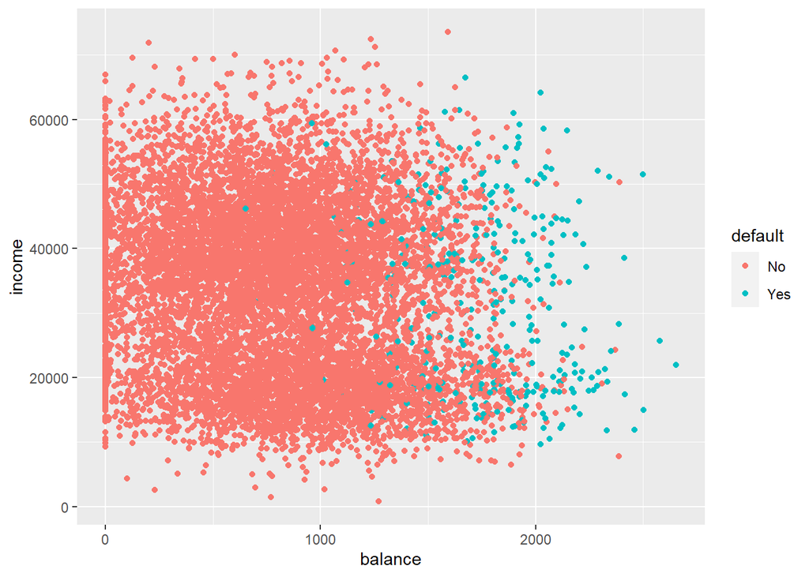

```r
attach(Default)

ggplot(Default, aes(x=balance,y=income,col=default))+geom_point()
```

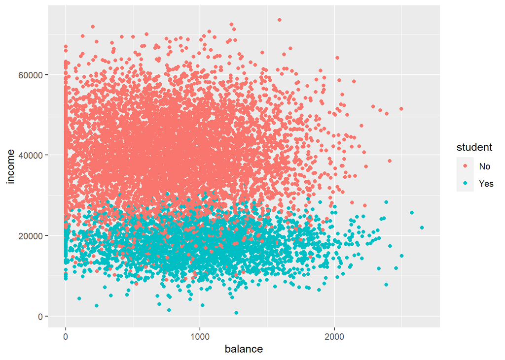

```r
ggplot(Default, aes(x=balance,y=income,col=student))+geom_point()
```

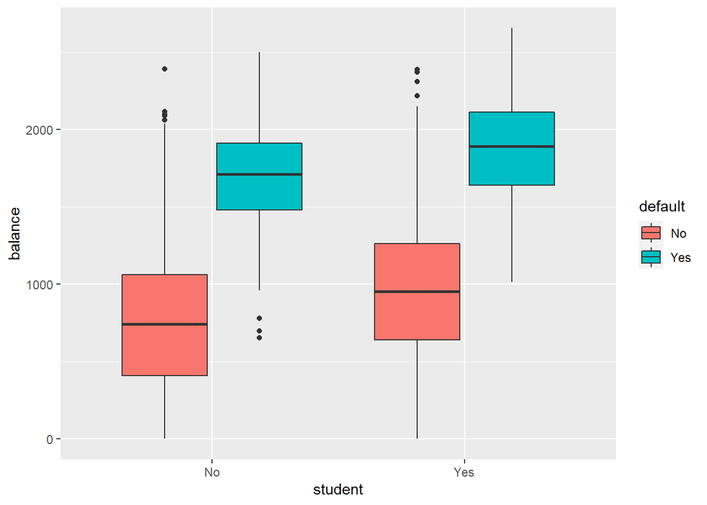

```r
ggplot(Default,aes(x=student,y=balance,fill=default))+geom_boxplot()
```

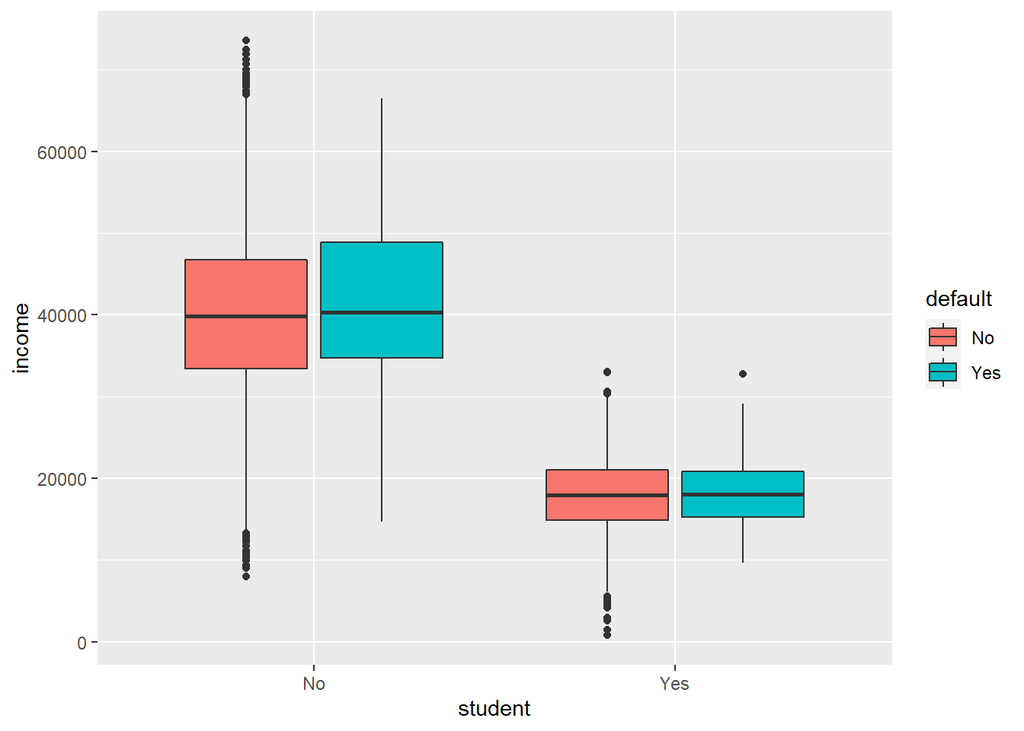

```r
ggplot(Default,aes(x=student,y=income,fill=default))+geom_boxplot()
```

Se puede ver que las variables balance y student parecen tener vinculacion con la variable default, pero que no ocurre lo mismo con la variables income.

```r
salida1=glm(default~.,family = binomial,data=Default)
salsum=summary(salida1)

salsum
```

```
##
## Call:
## glm(formula = default ~ ., family = binomial, data = Default)
##
## Deviance Residuals:
##     Min       1Q   Median       3Q      Max
## -2.4691  -0.1418  -0.0557  -0.0203   3.7383
##
## Coefficients:
##               Estimate Std. Error z value Pr(>|z|)
## (Intercept) -1.087e+01  4.923e-01 -22.080  < 2e-16 ***
## studentYes  -6.468e-01  2.363e-01  -2.738  0.00619 **
## balance      5.737e-03  2.319e-04  24.738  < 2e-16 ***
## income       3.033e-06  8.203e-06   0.370  0.71152
## ---
## Signif. codes:  0 '***' 0.001 '**' 0.01 '*' 0.05 '.' 0.1 ' ' 1
##
## (Dispersion parameter for binomial family taken to be 1)
##
##     Null deviance: 2920.6  on 9999  degrees of freedom
## Residual deviance: 1571.5  on 9996  degrees of freedom
## AIC: 1579.5
##
## Number of Fisher Scoring iterations: 8
```

```r
#Hacemos el test de deviance

1-pchisq(salida1$null.deviance-salida1$deviance, salida1$df.null-salida1$df.residual)
```

```
## [1] 0
```

En cuanto a la significatividad del modelo el test de la deviance dice que el modelo es significativo. Por otra parte en los test individuales, vemos como sospechabamos al principio que la variables $\mathtt{income}$ no es significatica. Por otra parte, como el coeficiente que acompania a la variable $\mathtt{balance}$ es positivo a mayor balance mas probabilidad de defaultear la tarjeta. Mientras que el coeficiente que acompania a la variable $\mathtt{student}$ es negativo, indicando que los estudiantes tienen menor probabilidad de defaultear la tarjeta.

A continuacion calculamos los intervalos de confianza para los coeficientes, ademas de los intervalos de confianza para $e^{\beta}$ que indica como varia la razon de probabilidades.

```r
#calculamos los intervalos de confianza

confint(salida1)
```

```
##                     2.5 %        97.5 %
## (Intercept) -1.185902e+01 -9.928174e+00
## studentYes  -1.109018e+00 -1.822147e-01
## balance      5.294898e-03  6.204587e-03
## income      -1.304712e-05  1.912447e-05
```

```r
exp(confint(salida1))
```

```
##                    2.5 %       97.5 %
## (Intercept) 7.074481e-06 0.0000487808
## studentYes  3.298827e-01 0.8334223982
## balance     1.005309e+00 1.0062238757
## income      9.999870e-01 1.0000191246
```

A continuacion procedemos a seleccionar variables mediante el criterio de Akaike, el modelo que selecciona excluye a la variable $\mathtt{income},$ esto es consistente con el analisis que hicimos anteriormente.

```r
step(salida1)
```

```
## Start:  AIC=1579.54
## default ~ student + balance + income
##
##           Df Deviance    AIC
## - income   1   1571.7 1577.7
## <none>         1571.5 1579.5
## - student  1   1579.0 1585.0
## - balance  1   2907.5 2913.5
##
## Step:  AIC=1577.68
## default ~ student + balance
##
##           Df Deviance    AIC
## <none>         1571.7 1577.7
## - student  1   1596.5 1600.5
## - balance  1   2908.7 2912.7
```

```
##
## Call:  glm(formula = default ~ student + balance, family = binomial,
##     data = Default)
##
## Coefficients:
## (Intercept)   studentYes      balance
##  -10.749496    -0.714878     0.005738
##
## Degrees of Freedom: 9999 Total (i.e. Null);  9997 Residual
## Null Deviance:       2921
## Residual Deviance: 1572  AIC: 1578
```

```r
salida2=glm(default~balance+student,family = binomial)
```

Por ultimo graficamos la probabilidad de defaultear la tarjeta, para diferentes valores de $\mathtt{balance},$ hay una curva para estudiantes y otra para no estudiantes.

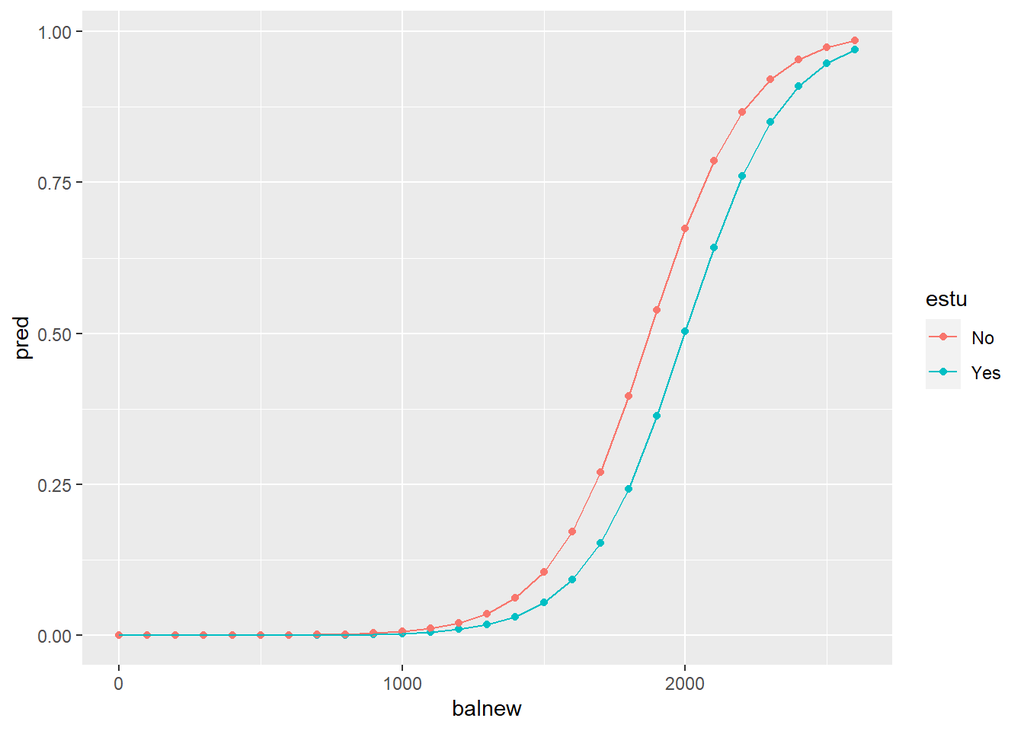

```r
bal.new=seq(min(balance),max(balance),100)
new.est=data.frame(balance=bal.new,student=factor(rep("Yes",length(bal.new))))
pred.est=predict(salida2,newdata = new.est,type="response")
new.no.est=data.frame(balance=bal.new,student=factor(rep("No",length(bal.new))))
pred.no.est=predict(salida2,newdata = new.no.est,type="response")
df=data.frame(balnew=c(bal.new,bal.new),pred=c(pred.est,pred.no.est),estu=rep(c("Yes","No"),each=length(bal.new)))
ggplot(df, aes(x=balnew,y=pred,group=estu))+  geom_point(aes(color=estu))+
geom_line(aes(color=estu))
```

A igualdad de balance la probabilidad de defaultear la tarjeta siempre es menor para un estudiante.

A continuacion hacemos las predicciones, para esto se predicen las probabilidades de defaultear la tarjeta y luego se pone una cota por encima de la cual se clasifica al individuo con $\mathtt{default}=1,$ es decir se predice que no va a pagar la tarjeta. Dependiendo de la cota que se fije, se modifica el error global, asi como tambien la sensitividad y especificidad. En este caso la cota esta fijada en $p=0.5,$ pero este valor se puede cambiar.

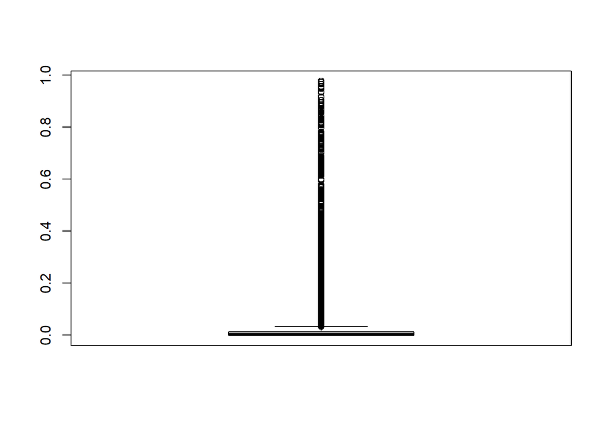

```r
predicciones=predict(salida2,type="response")
boxplot(predicciones)
```

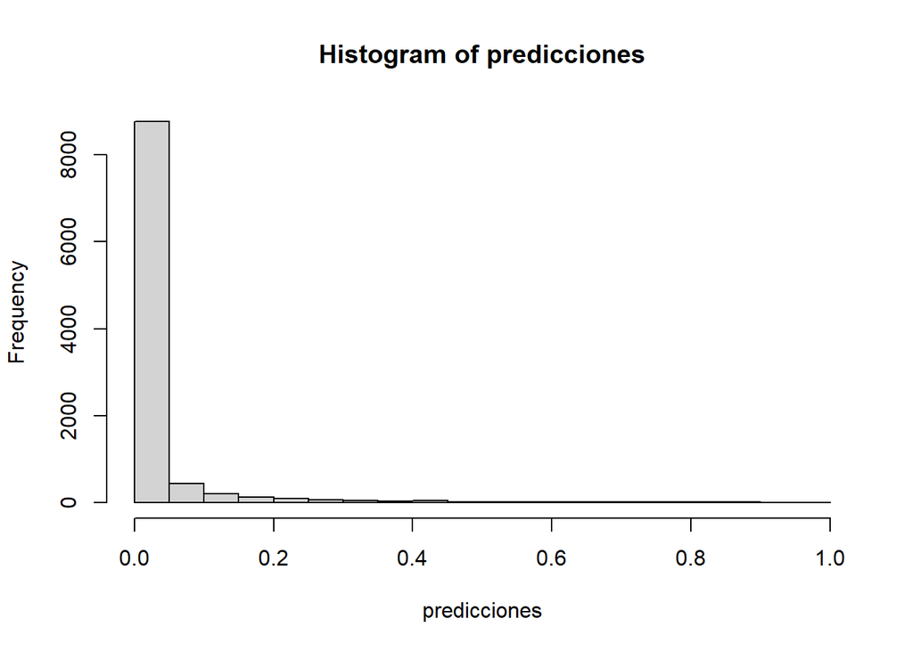

```r
hist(predicciones)
```

```r
def.pred=rep("No",length(predicciones))
p0=0.5
def.pred[predicciones>p0]="Yes"
confmat=table(default,def.pred,dnn = c("Real", "Predicha"))
confmat
```

```
##      Predicha
## Real    No  Yes
##   No  9628   39
##   Yes  228  105
```

```r
library(caret)
cm.log.def=confusionMatrix(confmat)
cm.log.def
```

```
## Confusion Matrix and Statistics
##
##      Predicha
## Real    No  Yes
##   No  9628   39
##   Yes  228  105
##
##                Accuracy : 0.9733
##                  95% CI : (0.9699, 0.9764)
##     No Information Rate : 0.9856
##     P-Value [Acc > NIR] : 1
##
##                   Kappa : 0.4288
##
##  Mcnemar's Test P-Value : <2e-16
##
##             Sensitivity : 0.9769
##             Specificity : 0.7292
##          Pos Pred Value : 0.9960
##          Neg Pred Value : 0.3153
##              Prevalence : 0.9856
##          Detection Rate : 0.9628
##    Detection Prevalence : 0.9667
##       Balanced Accuracy : 0.8530
##
##        'Positive' Class : No
##
```

```r
def.pred=rep("No",length(predicciones))
p0=0.4
def.pred[predicciones>p0]="Yes"
confmat=table(default,def.pred,dnn = c("Real", "Predicha"))
confmat
```

```
##      Predicha
## Real    No  Yes
##   No  9590   77
##   Yes  197  136
```

```r
cm.log.def=confusionMatrix(confmat)
cm.log.def
```

```
## Confusion Matrix and Statistics
##
##      Predicha
## Real    No  Yes
##   No  9590   77
##   Yes  197  136
##
##                Accuracy : 0.9726
##                  95% CI : (0.9692, 0.9757)
##     No Information Rate : 0.9787
##     P-Value [Acc > NIR] : 1
##
##                   Kappa : 0.4848
##
##  Mcnemar's Test P-Value : 6.524e-13
##
##             Sensitivity : 0.9799
##             Specificity : 0.6385
##          Pos Pred Value : 0.9920
##          Neg Pred Value : 0.4084
##              Prevalence : 0.9787
##          Detection Rate : 0.9590
##    Detection Prevalence : 0.9667
##       Balanced Accuracy : 0.8092
##
##        'Positive' Class : No
##
```

Analizamos la evolucion de la especificidad y sensitividad para diferentes posibles cortes en la clasificacion.

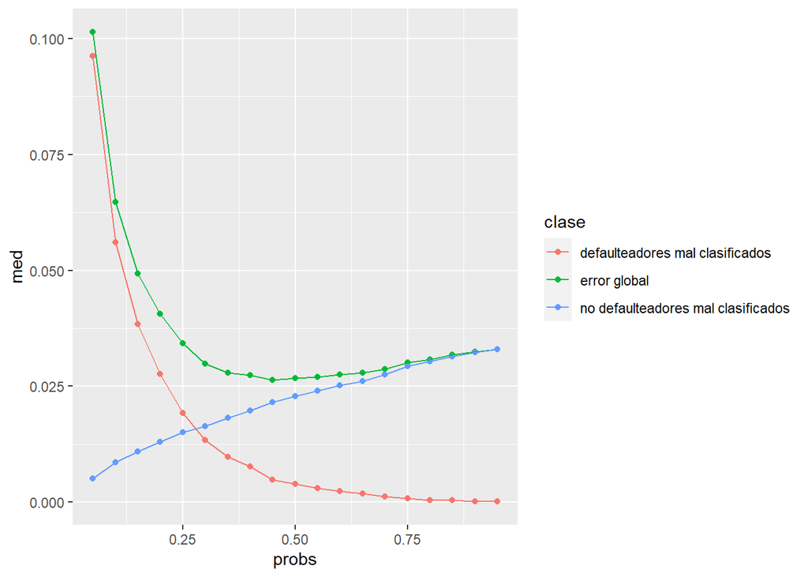

```r
p_0=seq(0.05,0.95,0.05)
error.global=vector(length = length(p_0))
def.mal.class=vector(length = length(p_0))
no.def.mal.class=vector(length = length(p_0))

for (i in 1:length(p_0)){
  def.pred=rep("No",length(predicciones))
  def.pred[predicciones>p_0[i]]="Yes"
  confmat=table(default,def.pred,dnn = c("Real", "Predicha"))
  error.global[i]=(confmat[1,2]+confmat[2,1])/length(predicciones)
  def.mal.class[i]=confmat[1,2]/length(predicciones)
  no.def.mal.class[i]= confmat[2,1]/length(predicciones)
  }



df=data.frame(probs=c(p_0,p_0,p_0),med=c(error.global,def.mal.class,no.def.mal.class),clase=rep(c("error global","defaulteadores mal clasificados","no defaulteadores mal clasificados"),each=length(p_0)))
ggplot(df, aes(x=probs,y=med,group=clase))+  geom_point(aes(color=clase))+
geom_line(aes(color=clase))
```

```r
library(InformationValue)
optCutOff=optimalCutoff(default,predicciones)
p_0=optCutOff[1]

def.pred=rep("No",length(predicciones))

def.pred[predicciones>p_0]="Yes"
confmat=table(default,def.pred,dnn = c("Real", "Predicha"))
confmat
```

```
##      Predicha
## Real    No  Yes
##   No  6790 2877
##   Yes    9  324
```

Si bien en este ejemplo especifico la seleccion de variables realizada utilizando el criterio de Akaike fue adecuada, si tuvieramos muchas variables seria conveniente seleccionar las variables ajustar el modelo mediante un estimador LASSO. El analisis es analogo al realizado en regresion lineal. El parametro de penalidad $\lambda$ se encuentra por convalidacion cruzada.

En este caso las dos muestras no son equilibradas, solamente el 3% de las observaciones defaultean la tarjeta. Veamos como generar en la muestra de entrenamiento muestras balanceadas, para eso utilizaremos el metodo hibrido SMOTE.

En primer lugar separo una muestra de validacion y una de testeo, las elijo de forma tal que en esas queden representadas las dos clases.

```r
set.seed(135)
ind.def.si=which(default=="Yes")
ind.def.no=which(default=="No")

#tomo la training con la misma proporcion de datos de default que la muestra original
train.index.ds=sample(ind.def.si,0.75*length(ind.def.si))
train.index.dn=sample(ind.def.no,0.75*length(ind.def.no))

train.index=sort(c(train.index.ds,train.index.dn))


train=Default[train.index,]
test=Default[-train.index,]


# Ahora voy a balancear la muestra de entrenamiento usando SMOTE
library(DMwR)
#Hacemos una nueva muestra
newtrain <- SMOTE(default ~ balance+student, train, perc.over = 400,perc.under=100)
#Verificamos que se mantiene la poblacion
table(newtrain$default)
```

```
##
##   No  Yes
##  996 1245
```

```r
#Ajustamos el modelo logistico a la muestra balanceada
sal.smote=glm(default ~ balance+student,data=newtrain,family="binomial")
sal.smote2=summary(sal.smote)
# depende de dos parametros
#perc.over= este numero rige la cantidade de observaciones que se originaran de la clase minoritaria,
#nro mayor a 100, perc.over/100 indica la cantidad de observaciones que hay que generar por cada ua dela clase minoritaria
#perc.under=controla la cantidad de observaciones de la muestra mayoritaria que seran elegidas en la muestra nueva de la clase mayoritariaeste numero rige la cantidade de observaciones que se originaran de la clase mayoritaria.

#podemos tener automaticamente el modelo
#newtrain <- SMOTE(default ~ balance+student, train, perc.over = 300,perc.under=100,learner = 'glm',family="binomial")
#summary(newtrain)
```

Vamos a ver como cambian las predicciones al cambiar las muestras.

```r
pred.smote=predict(sal.smote,newdata = test,type="response")

def.pred=rep("No",length(pred.smote))
p0=0.5
def.pred[pred.smote>p0]="Yes"
confmat=table(test$default,def.pred,dnn = c("Real", "Predicha"))
confmat
```

```
##      Predicha
## Real    No  Yes
##   No  2085  332
##   Yes    7   77
```

```r
pred.sal2=predict(salida2,newdata = test,type="response")
p0=0.5
def.pred2=rep("No",length(pred.sal2))
def.pred2[pred.sal2>p0]="Yes"
confmat2=table(test$default,def.pred2,dnn = c("Real", "Predicha"))
confmat2
```

```
##      Predicha
## Real    No  Yes
##   No  2411    6
##   Yes   62   22
```

En este caso disminuye la probabilidad de clasificar a un como NO defaulteador a alguien que defaultea.

```r
library(glmnet)
```

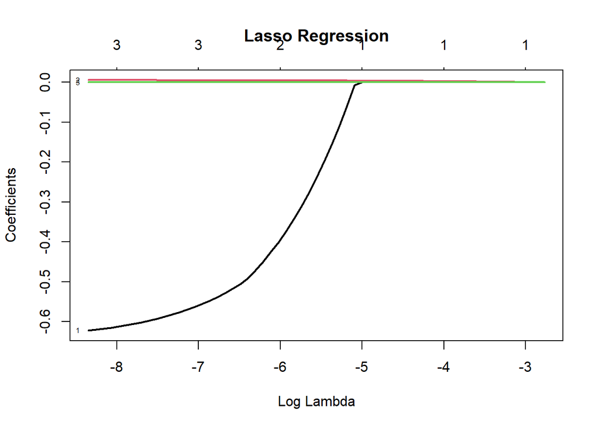

```r
library(caret)
x <- model.matrix(salida1)[,-1]
ajuste.lasso=glmnet(x, Default$default, family = "binomial", alpha = 1)
plot(ajuste.lasso, label = T, xvar="lambda",lwd=2, main="Lasso Regression")
```

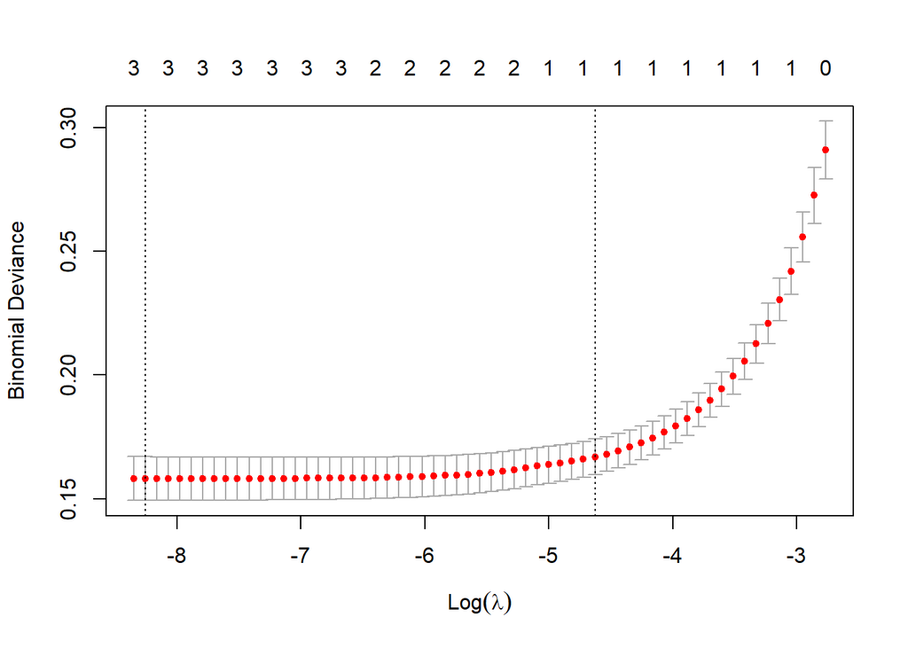

```r
#Cross validamos el parametro $\lambda$

cv.lasso <- cv.glmnet(x, Default$default, alpha = 1, family = "binomial")

plot(cv.lasso)
```

```r
#Ajustamos el modelo
lasso.cv <- glmnet(x, Default$default, alpha = 1, family = "binomial",
                lambda = cv.lasso$lambda.1sd)

coef(lasso.cv,cv.lasso$lambda.1se)
```

```
## 4 x 1 sparse Matrix of class "dgCMatrix"
##                        1
## (Intercept) -8.096494641
## studentYes   .
## balance      0.003866192
## income       .
```

Este problema lo podriamos haber analizado utilizando otra funcion de enlace, $\mathtt{probit},$ que es la inversa de la funcion de distribucion acumuladad de una distribucion normal estandar.

```r
salida3=glm(default ~ ., family = binomial(link = "probit"),data = Default)

sumsal3=summary(salida3)

sumsal3
```

```
##
## Call:
## glm(formula = default ~ ., family = binomial(link = "probit"),
##     data = Default)
##
## Deviance Residuals:
##     Min       1Q   Median       3Q      Max
## -2.2226  -0.1354  -0.0321  -0.0044   4.1254
##
## Coefficients:
##               Estimate Std. Error z value Pr(>|z|)
## (Intercept) -5.475e+00  2.385e-01 -22.960   <2e-16 ***
## studentYes  -2.960e-01  1.188e-01  -2.491   0.0127 *
## balance      2.821e-03  1.139e-04  24.774   <2e-16 ***
## income       2.101e-06  4.121e-06   0.510   0.6101
## ---
## Signif. codes:  0 '***' 0.001 '**' 0.01 '*' 0.05 '.' 0.1 ' ' 1
##
## (Dispersion parameter for binomial family taken to be 1)
##
##     Null deviance: 2920.6  on 9999  degrees of freedom
## Residual deviance: 1583.2  on 9996  degrees of freedom
## AIC: 1591.2
##
## Number of Fisher Scoring iterations: 8
```

Comenzamos haciendo un analisis descriptivo de los datos.

```r
library(sandwich)
library(msm)
p <- read.csv("https://stats.idre.ucla.edu/stat/data/poisson_sim.csv")
p <- within(p, {
  prog <- factor(prog, levels=1:3, labels=c("General", "Academic",
                                            "Vocational"))
  id <- factor(id)
})
summary(p)
```

```
##        id        num_awards           prog          math
##  1      :  1   Min.   :0.00   General   : 45   Min.   :33.00
##  2      :  1   1st Qu.:0.00   Academic  :105   1st Qu.:45.00
##  3      :  1   Median :0.00   Vocational: 50   Median :52.00
##  4      :  1   Mean   :0.63                    Mean   :52.65
##  5      :  1   3rd Qu.:1.00                    3rd Qu.:59.00
##  6      :  1   Max.   :6.00                    Max.   :75.00
##  (Other):194
```

```r
#analizamos medias y desvios por programa.

with(p, tapply(num_awards, prog, function(x) {
  sprintf("M (SD) = %1.2f (%1.2f)", mean(x), sd(x))
}))
```

```
##                General               Academic             Vocational
## "M (SD) = 0.20 (0.40)" "M (SD) = 1.00 (1.28)" "M (SD) = 0.24 (0.52)"
```

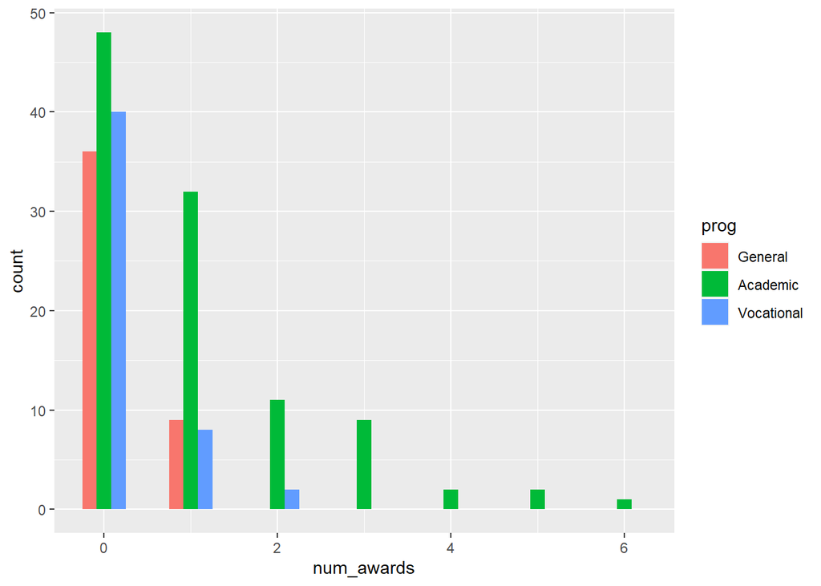

```r
ggplot(p, aes(num_awards, fill = prog)) +
  geom_histogram(binwidth=.5, position="dodge")
```

La media mas alta es la de academinca y la mas baja es la del general. En relacion a la cantidad de premios que obtienen se puede ver que solamente obtiennen mas de 3 premios estudiantes del track $\mathtt{Academic}$ y que los del track $\mathtt{General}$ a lo sumo obtienen un premio.

Ahora hacemos la regresion de poisson.

```r
m1= glm(num_awards ~ prog + math, family="poisson", data=p)
salpremio=summary(m1)
salpremio
```

```
##
## Call:
## glm(formula = num_awards ~ prog + math, family = "poisson", data = p)
##
## Deviance Residuals:
##     Min       1Q   Median       3Q      Max
## -2.2043  -0.8436  -0.5106   0.2558   2.6796
##
## Coefficients:
##                Estimate Std. Error z value Pr(>|z|)
## (Intercept)    -5.24712    0.65845  -7.969 1.60e-15 ***
## progAcademic    1.08386    0.35825   3.025  0.00248 **
## progVocational  0.36981    0.44107   0.838  0.40179
## math            0.07015    0.01060   6.619 3.63e-11 ***
## ---
## Signif. codes:  0 '***' 0.001 '**' 0.01 '*' 0.05 '.' 0.1 ' ' 1
##
## (Dispersion parameter for poisson family taken to be 1)
##
##     Null deviance: 287.67  on 199  degrees of freedom
## Residual deviance: 189.45  on 196  degrees of freedom
## AIC: 373.5
##
## Number of Fisher Scoring iterations: 6
```

Veamos las predicciones considerando el puntaje medio en $\mathtt{math}$ para cada uno de los programas.

```r
s1=data.frame(math=mean(p$math),prog=factor(1:3,levels=1:3,labels=levels(p$prog)))
predict(m1, s1, type="response", se.fit=TRUE)
```

```
## $fit
##         1         2         3
## 0.2114109 0.6249446 0.3060086
##
## $se.fit
##          1          2          3
## 0.07050108 0.08628117 0.08833706
##
## $residual.scale
## [1] 1
```

Ahora veamos como ajusta el modelo graficamente.

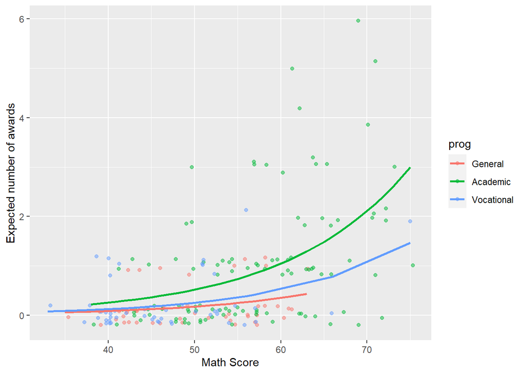

```r
p$phat <- predict(m1, type="response")

## ordeno por programa y por nota de math
p <- p[with(p, order(prog, math)), ]

## graficamos
ggplot(p, aes(x = math, y = phat, colour = prog)) +
  geom_point(aes(y = num_awards), alpha=.5, position=position_jitter(h=.2)) +
  geom_line(size = 1) +
  labs(x = "Math Score", y = "Expected number of awards")
```